# Predict activity quality based on measures from wearables

Giordano Alvitez F.

Nowadays people try to do exercise whenever they can, but they actually do not know if they do exercise correctly and avoid any injuries. So, this project’s goal determining when people do an exercise correctly or not based on some collected measures from wearables.

## Downloading Training and Test Data

The data for this project comes from http://web.archive.org/web/20161224072740/http:/groupware.les.inf.puc-rio.br/har

## Loading Data and libraries

Before loading the data, it is neccesary to look inside the files how it is structured. So, I noticed it has many empty strings (""), so we need to define na values in the *read.csv* function.

## Cleaning Data

One interesting thing is look at how NA values we have. In order to check how NA values are distributed is with the image. The color red represents when we have a NA values in our data, in other case is not a NA value.

```r
datos_long <- training %>% gather(key = "variable", value = "valor", -X)
```

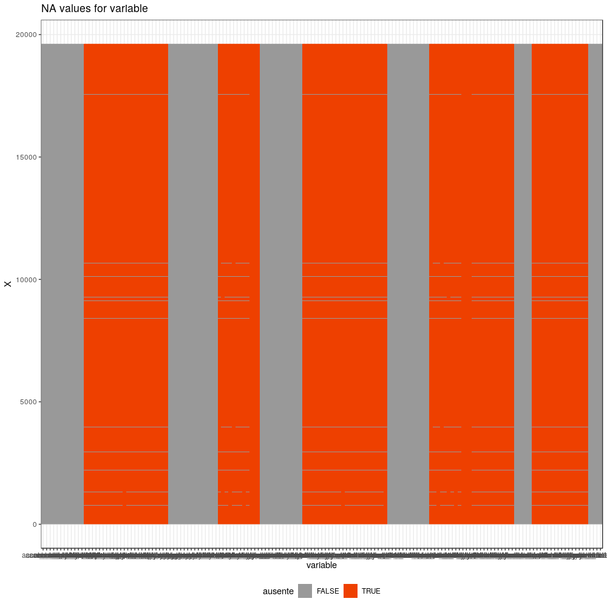

```r
datos_long <- datos_long %>%  mutate(ausente = is.na(valor))

png(file="na_values.png", res=96, width=1000, height=1000)
ggplot(data = datos_long, aes(x = variable, y = X, fill = ausente)) +
  geom_raster() +
  scale_fill_manual(values = c("gray60", "orangered2")) +
  theme_bw() +
  labs(title = "NA values for variable") +
  theme(legend.position = "bottom")
dev.off()
```

It is totally clear that there are a lot of NA values in our dataset. So we need to exclude them in our analysis. Additionally, we can use the funcion *map_dbl* to see how many NA values for each variable we have in our data after cleaning.

```r
index_notNA <- colSums(is.na(training)) == 0 & colSums(is.na(testing)) == 0
training <- training[,index_notNA]
testing <- testing[,index_notNA]

#sort(colnames(train)) == sort(colnames(test))
#setdiff(colnames(train), colnames(test))
#setdiff(colnames(test), colnames(train))

map_dbl(training, .f = function(x){sum(is.na(x))})
```

```
##                    X            user_name raw_timestamp_part_1
##                    0                    0                    0
## raw_timestamp_part_2       cvtd_timestamp           new_window
##                    0                    0                    0
##           num_window            roll_belt           pitch_belt
##                    0                    0                    0
##             yaw_belt     total_accel_belt         gyros_belt_x
##                    0                    0                    0
##         gyros_belt_y         gyros_belt_z         accel_belt_x
##                    0                    0                    0
##         accel_belt_y         accel_belt_z        magnet_belt_x
##                    0                    0                    0
##        magnet_belt_y        magnet_belt_z             roll_arm
##                    0                    0                    0
##            pitch_arm              yaw_arm      total_accel_arm
##                    0                    0                    0
##          gyros_arm_x          gyros_arm_y          gyros_arm_z
##                    0                    0                    0
##          accel_arm_x          accel_arm_y          accel_arm_z
##                    0                    0                    0
##         magnet_arm_x         magnet_arm_y         magnet_arm_z
##                    0                    0                    0
##        roll_dumbbell       pitch_dumbbell         yaw_dumbbell
##                    0                    0                    0
## total_accel_dumbbell     gyros_dumbbell_x     gyros_dumbbell_y
##                    0                    0                    0
##     gyros_dumbbell_z     accel_dumbbell_x     accel_dumbbell_y
##                    0                    0                    0
##     accel_dumbbell_z    magnet_dumbbell_x    magnet_dumbbell_y
##                    0                    0                    0
##    magnet_dumbbell_z         roll_forearm        pitch_forearm
##                    0                    0                    0
##          yaw_forearm  total_accel_forearm      gyros_forearm_x
##                    0                    0                    0
##      gyros_forearm_y      gyros_forearm_z      accel_forearm_x
##                    0                    0                    0
##      accel_forearm_y      accel_forearm_z     magnet_forearm_x
##                    0                    0                    0
##     magnet_forearm_y     magnet_forearm_z               classe
##                    0                    0                    0
```

Additionally, I noticed the first seven variables do not offer any important information because they are string or incremental variables.

```r
str(training)
```

```
## 'data.frame':    19622 obs. of  60 variables:
##  $ X                   : int  1 2 3 4 5 6 7 8 9 10 ...
##  $ user_name           : Factor w/ 6 levels "adelmo","carlitos",..: 2 2 2 2 2 2 2 2 2 2 ...
##  $ raw_timestamp_part_1: int  1323084231 1323084231 1323084231 1323084232 1323084232 1323084232 1323084232 1323084232 1323084232 1323084232 ...
##  $ raw_timestamp_part_2: int  788290 808298 820366 120339 196328 304277 368296 440390 484323 484434 ...
##  $ cvtd_timestamp      : Factor w/ 20 levels "02/12/2011 13:32",..: 9 9 9 9 9 9 9 9 9 9 ...
##  $ new_window          : Factor w/ 2 levels "no","yes": 1 1 1 1 1 1 1 1 1 1 ...
##  $ num_window          : int  11 11 11 12 12 12 12 12 12 12 ...
##  $ roll_belt           : num  1.41 1.41 1.42 1.48 1.48 1.45 1.42 1.42 1.43 1.45 ...
##  $ pitch_belt          : num  8.07 8.07 8.07 8.05 8.07 8.06 8.09 8.13 8.16 8.17 ...
##  $ yaw_belt            : num  -94.4 -94.4 -94.4 -94.4 -94.4 -94.4 -94.4 -94.4 -94.4 -94.4 ...
##  $ total_accel_belt    : int  3 3 3 3 3 3 3 3 3 3 ...
##  $ gyros_belt_x        : num  0 0.02 0 0.02 0.02 0.02 0.02 0.02 0.02 0.03 ...
##  $ gyros_belt_y        : num  0 0 0 0 0.02 0 0 0 0 0 ...
##  $ gyros_belt_z        : num  -0.02 -0.02 -0.02 -0.03 -0.02 -0.02 -0.02 -0.02 -0.02 0 ...
```

[output cut: 46 more lines]

So, we omit columns from one to seven.

```r
training <- training[,-c(1:7)]
testing <- testing[,-c(1:7)]
```

## Partition

```r
set.seed(123)
indexTrain <- createDataPartition(y=training$classe, p=0.7, list=FALSE)
training_tr <- training[indexTrain, ]
valid <- training[-indexTrain, ]
```

Another fact, it find which variables are highly correlated. If we can find them, we can omit some of them in order to get loss computational load but still have a good accuracy. For that purpose, we use *corrplot* with order set to hclust to see some possible omissions in our analysis.

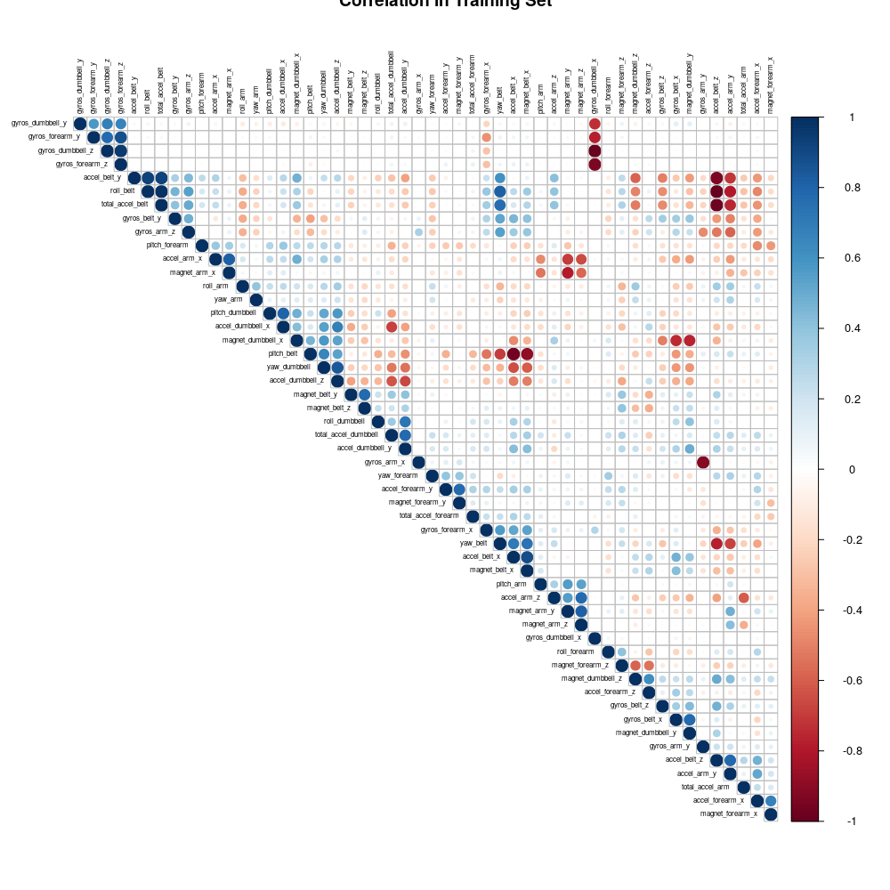

```r
png(file="correlation_train.png", res=96, width=1000, height=1000)
corrplot(cor(training_tr[, -53]), order = "hclust", tl.cex = 0.5, type = "upper", tl.col = "black", title = "Correlation in Training Set")
dev.off()
```

In order to figure out how many variables are highly related each other, we could filter with *which* function.

```r
M <- abs(cor(training_tr[,-53]));
diag(M) <- 0
paste("There are ", dim(which(M > 0.72, arr.ind = T))[1] / 2, "variables highly correlated each other.")
```

```
## [1] "There are  37 variables highly correlated each other."
```

Later, in order to scale with our methodology, I will use only variable which give me 95% of explanation about the data with PCA.

```r
set.seed(123)
pp_pca <- preProcess(training_tr[,-53],method="pca", thresh=0.95)
```

In this case, we need to reformat out valid and training_tr data set.

```r
classes <- unique(training_tr$classe)
training_pca <- predict(pp_pca, training_tr[,-53])
training_pca$classe <- training_tr$classe

valid_pca <- predict(pp_pca, valid[,-53])
valid_pca$classe <- valid$classe
```

### Support Vector Machine - SVM

My first intuition is using SVM with kernelization.

```r
set.seed(123)

control_train <- trainControl(method = "repeatedcv", number = 3,
                              repeats = 2, returnResamp = "final", verboseIter = FALSE,allowParallel = TRUE)

hiperparametros <- expand.grid(sigma = c(0.001, 0.01, 0.1, 0.5, 1),
                               C = c(1 , 20, 50, 100, 200, 500, 700))

modelo_svm <- train(classe ~ ., data = training_pca,
                   method = "svmRadial",
                   tunidGrid = hiperparametros,
                   metric = "Accuracy",
                   trControl = control_train)


predicted_svm <- predict(modelo_svm, valid_pca)
confusion_matrix_svm <- confusionMatrix(valid$classe,predicted_svm)

plt <- as.data.frame(round(prop.table(confusion_matrix_svm$table), 2))


plt$Prediction <- factor(plt$Prediction, levels=rev(levels(plt$Prediction)))

png(file="cm_svm.png", res=96, width=1000, height=1000)
ggplot(plt, aes(Prediction,Reference, fill= Freq)) +
        geom_tile() + geom_text(aes(label=Freq)) +
        scale_fill_gradient(low="white", high="#009194") +
        labs(x = "Reference",y = "Prediction") +
        scale_x_discrete(labels= classes) +
        scale_y_discrete(labels=rev(classes))
dev.off()
```

Getting 0.9087511 of precision with the valid.

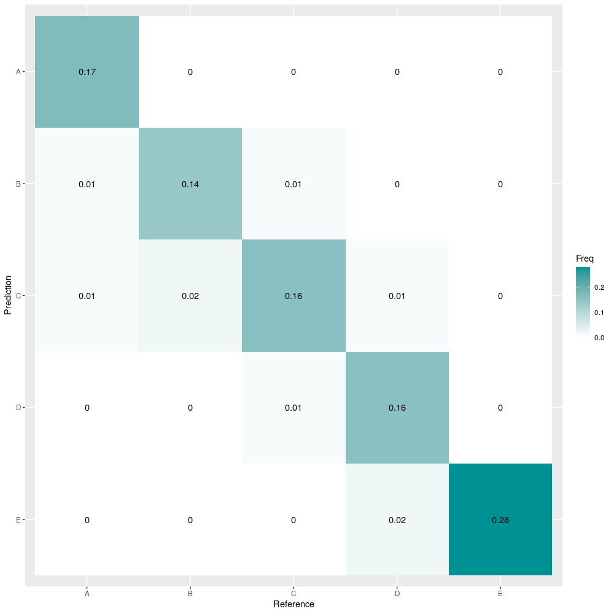

Confusion Matrix of SVM

### Decision Tree

In order to compere with another machine learning algorithm, I decided to used decision tree.

```r
control_train <- trainControl(method = "repeatedcv", number = 3, repeats = 2, returnResamp = "final", verboseIter = FALSE, allowParallel = TRUE)
modelo_dt <- train(classe~., data=training_pca, method="rpart", trControl=control_train)

predicted_dt <- predict(modelo_dt,newdata=valid_pca)
confusion_matrix_dt <- confusionMatrix(valid_pca$classe,predicted_dt)

plt_dt <- as.data.frame(round(prop.table(confusion_matrix_dt$table), 2))
plt_dt$Prediction <- factor(plt_dt$Prediction, levels=rev(levels(plt_dt$Prediction)))

png(file="cm_dt.png", res=96, width=1000, height=1000)
ggplot(plt_dt, aes(Prediction,Reference, fill= Freq)) +
        geom_tile() + geom_text(aes(label=Freq)) +
        scale_fill_gradient(low="white", high="#009194") +
        labs(x = "Reference",y = "Prediction") +
        scale_x_discrete(labels= classes) +
        scale_y_discrete(labels=rev(classes))
dev.off()
```

Unfortunately, I only got 0.3782498 of precision.

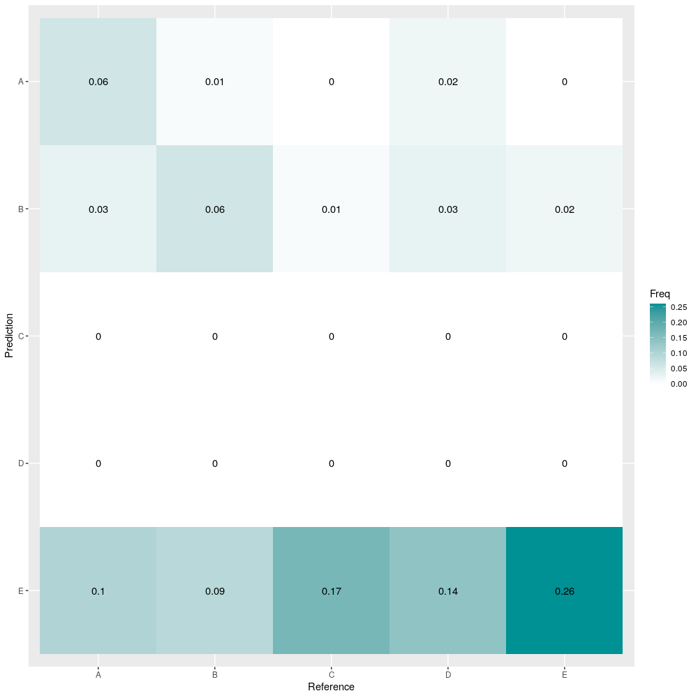

Confusion Matrix of Decision Tree.

### Random Forest

After using decision tree, I tried with random forest.

```r
control_train <- trainControl(method = "repeatedcv", number = 3, repeats = 2, returnResamp = "final", verboseIter = FALSE, allowParallel = TRUE)
model_rf <- train(classe~., data=training_pca, method="rf", trControl=control_train, verbose=FALSE)

predicted_rf <- predict(model_rf,newdata=valid_pca)
confusion_matrix_rf <- confusionMatrix(valid_pca$classe,predicted_rf)



plt_rf <- as.data.frame(round(prop.table(confusion_matrix_rf$table), 2))
plt_rf$Prediction <- factor(plt_rf$Prediction, levels=rev(levels(plt_rf$Prediction)))

png(file="cm_rf.png", res=96, width=1000, height=1000)
ggplot(plt_rf, aes(Prediction,Reference, fill= Freq)) +
        geom_tile() + geom_text(aes(label=Freq)) +
        scale_fill_gradient(low="white", high="#009194") +
        labs(x = "Reference",y = "Prediction") +
        scale_x_discrete(labels= classes) +
        scale_y_discrete(labels=rev(classes))
dev.off()
```

Fortunately, random forest gave me 0.9746814 of precision, so I took it to predict with test data.

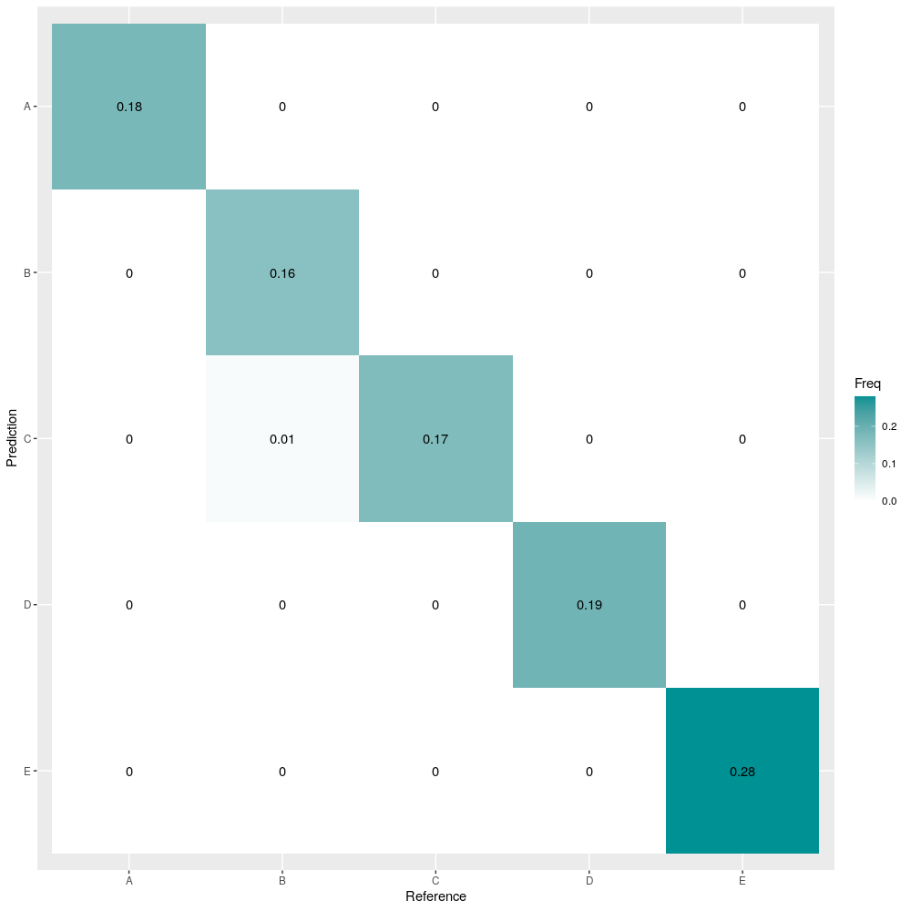

## Results

Finally, I used random forest to get the answers for the testing data.

```r
dim(testing)
```

```
## [1] 20 53
```

```r
testing_pc <- predict(pp_pca, testing[,-53])
predict(model_rf, testing_pc)
```

```
##  [1] B A B A A E D B A A B C B A E E A B B B
## Levels: A B C D E
```